# Clinical data pre-filtering

Hedda Fjell Scheel

2025-02-09

Pre-filtering workflow for clinical variables include univariate models (Log-rank + Cox) and multivariate model (Cox)

The tabs:

1. An overview of the data: Group sizes and sensoring status
2. Plotting the Kaplan Meier curves of clinical variables we are interested in + logrank tests: non-parametric
3. Exploring clinical variables in univariate cox models + comparing to logrank test
4. Multivariate Cox model using stepwise selection (“both” selection method)
5. Correlation plot for all clinical variables
6. Checking assumptions for Cox: proportional hazards and non-linearity.

```r
library(survival)
library(survminer)
library(glmnet)
library(DT)
library(c060)
library(arsenal)
library(caret)
library(gridExtra)
library(DESeq2)
library(tidyverse)
library(VIM) #for KNN impute
library(sjPlot)
library(sjmisc)
library(sjlabelled)
library(ggcorrplot)
load("data/tumor_samples_with_subtype.Rdata")
```

## 1) An overview of the data

### Descriptive table with clinical variables

In the dataset there are 157 dogs with sccessful alignment. Of these, 11 did not have a number ofdays to event/censoring annotated, so they are excluded from this survival analysis (loss to follow-up). Ten dogs had NAs for one or more of the clinical variables we will look at, and these missing values were imputed using the 5-nearest neighbours. Therefore, 146 dogs are included in the study.

```r
clin_vars <- c("Age", "Neuter_status", "Grade", "Lymphatic_invasion", "ER_status", "HER2_score", "Breed_Maltese", "Malignitet", "Subtype_MPAM50", "Breed", "Histology")
clinical_tbl <- tumor_samples_with_subtype %>%
  mutate(Subtype_MPAM50 = as.factor(subtype_MPAM50)) %>%
  kNN(variable = clin_vars, k=5) %>%
  drop_na("Survival_days") %>%
  mutate(Status_survival= as.factor(Status_survival)) %>%
  select(Sample_ID, all_of(clin_vars), Survival_days, Status_survival) %>%
  as_tibble()

carcinomas <- c("Spindle cell carcinoma (Malignant myoepithelioma)", "Simple carcinoma (Tubulopapillary type)", "Simple carcinoma (Anaplastic type)", "Simple carcinoma (Solid type)", "Complex carcinoma", "Carcinosarcoma", "Carcinoma in benign mixed tumor")
clinical_tbl <- clinical_tbl %>%
  mutate(Histology_gr = ifelse(Histology %in% carcinomas, "Carcinomas", "Others"))

table_descriptive <- tableby(~Age + Breed_Maltese + Neuter_status + Histology_gr + Grade + Lymphatic_invasion + ER_status +  HER2_score + Subtype_MPAM50, data = clinical_tbl)
labels(table_descriptive) <- c(Neuter_status = "Neuter status", Breed_Maltese = "Breed group",Histology_gr = "Histology group", Lymphatic_invasion = "Lymphatic invasion", ER_status = "ER status", HER2_score = "HER2 score", Subtype_MPAM50 = "MPAM50 Subtype")
summary(table_descriptive)
```

|  | Overall (N=146) |
| --- | --- |
| **Age** |  |
| Mean (SD) | 11.884 (2.820) |
| Range | 2.000 - 19.000 |
| **Breed group** |  |
| Maltese | 42 (28.8%) |
| Non-Maltese | 104 (71.2%) |
| **Neuter status** |  |
| Intact | 100 (68.5%) |
| Neutered | 46 (31.5%) |
| **Histology group** |  |
| Carcinomas | 108 (74.0%) |
| Others | 38 (26.0%) |
| **Grade** |  |
| Benign | 33 (22.6%) |
| 1 | 65 (44.5%) |
| 2 | 22 (15.1%) |
| 3 | 26 (17.8%) |
| **Lymphatic invasion** |  |
| Absent | 131 (89.7%) |
| Present | 15 (10.3%) |
| **ER status** |  |
| N | 23 (15.8%) |
| P | 123 (84.2%) |
| **HER2 score** |  |
| 0 | 12 (8.2%) |
| 1 | 26 (17.8%) |
| 2 | 72 (49.3%) |
| 3 | 36 (24.7%) |
| **MPAM50 Subtype** |  |
| Basal | 61 (41.8%) |
| LumA | 85 (58.2%) |

```r
Table_with_subtype <- table_descriptive <- tableby(Subtype_MPAM50 ~ Age + Breed_Maltese + Neuter_status + Histology_gr + Grade + Lymphatic_invasion + ER_status +  HER2_score , data = clinical_tbl)
#labels(table_descriptive) <- c(Neuter_status = "Neuter status", Breed_Maltese = "Breed group",Histology_gr = "Histology group", Lymphatic_invasion = "Lymphatic invasion", ER_status = "ER status", HER2_score = "HER2 score", subtype_MPAM50 = "MPAM50 Subtype")
summary(Table_with_subtype)
```

[output not shown]

### Overall censoring

In total, there are 146 dogs included in the analysis, of which 108 dogs are (right-)censored and 38 are non-censored. Dogs that died are annotated with “1” in the Status survival column and censored dogs are annotated with “0”. There is no information about cause of death for any of the dogs.

Folds for crossvalidaton are stratified by censoring for the entire analysis. (Not in this script)

```r
table(clinical_tbl$Status_survival)
```

```
##
##   0   1
## 108  38
```

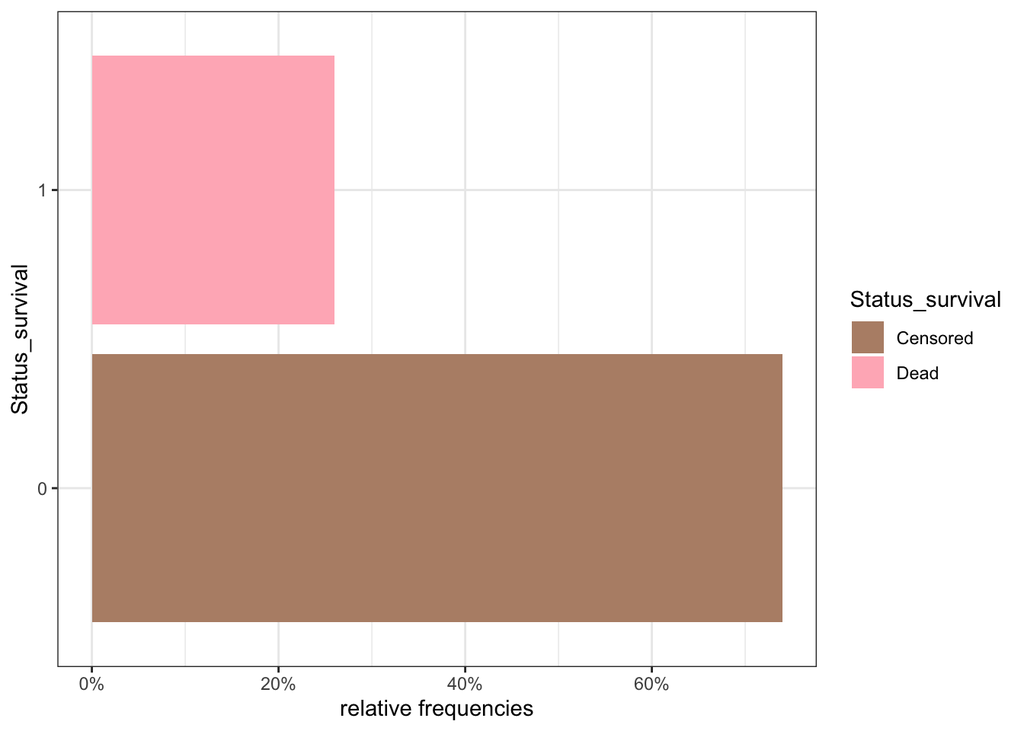

```r
ggplot(clinical_tbl, aes(x=Status_survival))+
  geom_bar(mapping=aes(y = after_stat(count)/sum(after_stat(count)), fill=Status_survival))+
  scale_y_continuous(labels=scales::percent) +
  ylab("relative frequencies")+
  scale_fill_discrete(labels=c("Censored", "Dead"), type =c("1"="lightpink", "0"="#b78f76"))+
  coord_flip()+
  theme_bw()
```

## 2) Kaplan Meier curves

### Kaplan Meier plots for the clinical and pathological variables

```r
clinical_tbl$Status_survival <- as.numeric(clinical_tbl$Status_survival)

## Age: 3 groups
clinical_tbl <- clinical_tbl %>%
  mutate(Age_3group = cut_number(Age, 3)) %>%
  mutate(Age_2group = ifelse(Age>mean(Age), ">11.85", "<11.85")) %>%
  mutate(Age_nonstd = Age)

fitAge3gr <- survfit(Surv(clinical_tbl$Survival_days, clinical_tbl$Status_survival)~Age_3group, data=clinical_tbl)
Age.plot <- ggsurvplot(fitAge3gr, data=clinical_tbl,
           pval = T,
           conf.int=F,
           #legend.title="Age",
           legend="none",
           palette= c("darkmagenta", "darkorange2", "forestgreen"),
           #legend.labs=c("2-11 years", ">11-13 years", ">13-19 years"),
           title= "Age",
           font.title = 25,
           font.x = 18,
           font.y = 18,
           xlab = "Days")

Age.plot$plot <- Age.plot$plot +
                              ggplot2::annotate("text",
                                x = 180, y = 0.07, # x and y coordinates of the text
                                label = "HR = 2.18", size = 5)

## Breed: Maltese
fitBreed1gr <- survfit(Surv(clinical_tbl$Survival_days, clinical_tbl$Status_survival)~Breed_Maltese, data=clinical_tbl)
Breed_Maltese.plot <- ggsurvplot(fitBreed1gr, data=clinical_tbl,
           pval = T,
           conf.int=F,
           legend.title="Breed",
           legend=c(0.8,0.2),
           legend.labs=c("Maltese", "other breeds"),
           title= "Breed",
           font.title = 25,
           font.x = 18,
           font.y = 18,
           xlab = "Days")


## Neuter status
fitNeuter <- survfit(Surv(clinical_tbl$Survival_days, clinical_tbl$Status_survival)~Neuter_status, data=clinical_tbl)
Neuter.plot <- ggsurvplot(fitNeuter, data=clinical_tbl,
           pval = T,
           conf.int=F,
           legend.title="Neuter status",
           legend=c(0.8,0.2),
           legend.labs=c("Intact", "Neutered"),
           title= "Neuter status",
           font.title = 25,
           font.x = 18,
           font.y = 18,
           xlab = "Days")


## Grade
clinical_tbl <- clinical_tbl %>%
  mutate(Grade_gr2 = replace(Grade, Grade == "2", "1"))
fitGradegr2 <- survfit(Surv(clinical_tbl$Survival_days, clinical_tbl$Status_survival)~Grade_gr2, data=clinical_tbl)
Grade.1.plot <- ggsurvplot(fitGradegr2, data=clinical_tbl,
           pval = T,
           conf.int=F,
           legend="none",
           title= "Tissue grade",
           palette= c("darkmagenta", "darkorange2", "forestgreen"),
           font.title = 25,
           font.x = 18,
           font.y = 18,
           xlab = "Days")

Grade.1.plot$plot <- Grade.1.plot$plot +
                              ggplot2::annotate("text",
                                x = 180, y = 0.07, # x and y coordinates of the text
                                label = "HR = 3.54", size = 5)


## Lymphatic invasion
fitLymph <- survfit(Surv(clinical_tbl$Survival_days, clinical_tbl$Status_survival)~Lymphatic_invasion, data=clinical_tbl)
Lymph_inv.plot <- ggsurvplot(fitLymph, data=clinical_tbl,
           pval = T,
           conf.int=F,
           legend="none",
           palette= c("darkmagenta", "darkorange2"),
           title= " Lymphatic invasion",
           font.title = 25,
           font.x = 18,
           font.y = 18,
           xlab = "Days")

Lymph_inv.plot$plot <- Lymph_inv.plot$plot +
                            ggplot2::annotate("text",
                                x = 180, y = 0.07, # x and y coordinates of the text
                                label = "HR = 4.38", size = 5)

## Histology group
fitHistology <- survfit(Surv(clinical_tbl$Survival_days, clinical_tbl$Status_survival)~Histology_gr, data=clinical_tbl)
Histology.plot <- ggsurvplot(fitHistology, data=clinical_tbl,
           pval = T,
           conf.int=F,
           legend.title="Histology class",
           legend=c(0.8,0.2),
           legend.labs=c("Carcinomas", "other"),
           title= "Histopathology",
           font.title = 25,
           font.x = 18,
           font.y = 18,
           xlab = "Days")

## ER status
fitER <- survfit(Surv(clinical_tbl$Survival_days, clinical_tbl$Status_survival)~ER_status, data=clinical_tbl)
ER.plot <- ggsurvplot(fitER, data=clinical_tbl,
           pval = T,
           conf.int=F,
           legend = "none",
           palette= c("red", "darkblue"),
           title= "ER status",
           font.title = 25,
           font.x = 18,
           font.y = 18,
           xlab = "Days")

ER.plot$plot <- ER.plot$plot +
                  ggplot2::annotate("text",
                                x = 120, y = 0.1, # x and y coordinates of the text
                                label = "HR = 0.35", size = 5)

## HER2 score
clinical_tbl <- clinical_tbl %>%
  mutate(HER2_gr = ifelse(HER2_score %in% c(0,1), 1, 2))

fitHER2 <- survfit(Surv(clinical_tbl$Survival_days, clinical_tbl$Status_survival)~HER2_gr, data=clinical_tbl)
HER2.plot <- ggsurvplot(fitHER2, data=clinical_tbl,
           pval = T,
           conf.int=F,
           legend.title="HER2 score",
           legend=c(0.8,0.2),
           legend.labs=c("Score 0-1", "Score 2-3"),
           title= "HER2 status",
           font.title = 25,
           font.x = 18,
           font.y = 18,
           xlab = "Days")

## subtype
fitMPAM <- survfit(Surv(clinical_tbl$Survival_days, clinical_tbl$Status_survival)~Subtype_MPAM50, data=clinical_tbl)
MPAM.plot <- ggsurvplot(fitMPAM, data=clinical_tbl,
           pval = T,
           conf.int=F,
           legend="none",
           palette= c("darkblue", "red"),
           title= "MPAM50 subtype",
           font.title = 25,
           font.x = 18,
           font.y = 18,
           xlab = "Days")

MPAM.plot$plot <- MPAM.plot$plot +
                     ggplot2::annotate("text",
                                x = 120, y = 0.1, # x and y coordinates of the text
                                label = "HR = 1.93", size = 5)
```

#### Dog information

The only variable with significant impact on survival is age. The survival measured in this study is overall survival (OS) and not tumor specific survival, therefore the effect seen here of age is not necessarily tumor related.

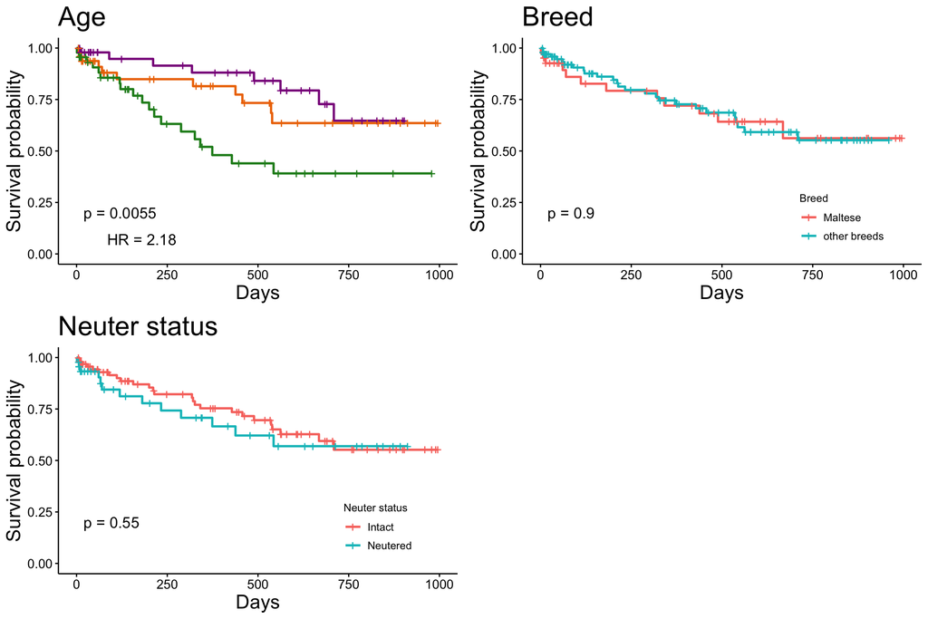

```r
arrange_ggsurvplots(list(Age.plot, Neuter.plot, Breed_Maltese.plot), ncol = 2, nrow = 2)
```

#### Tumor pathology

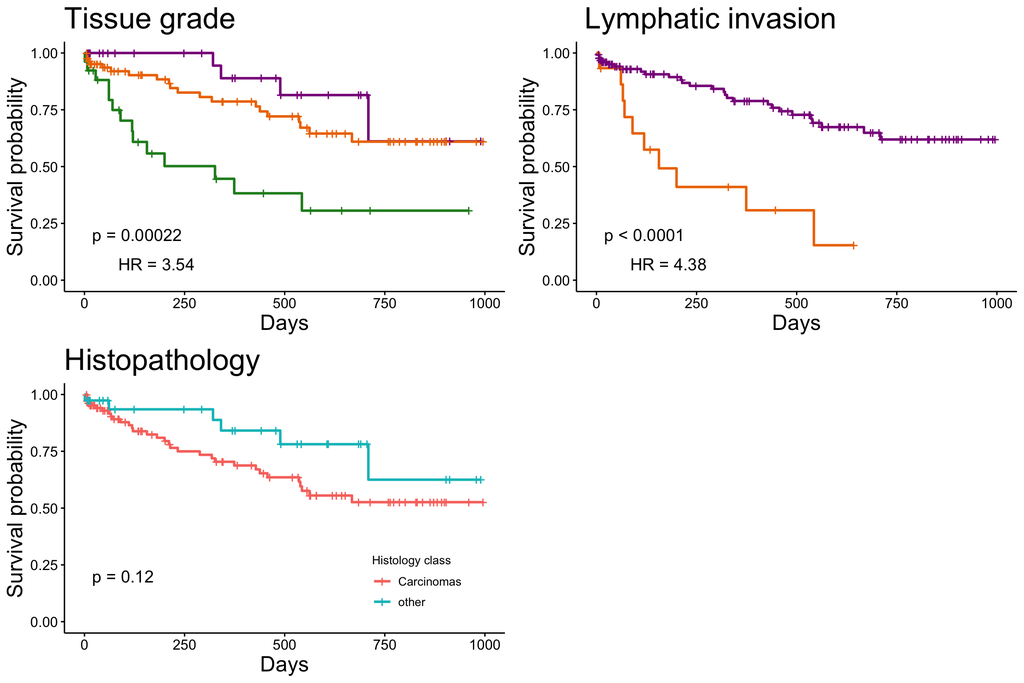

```r
arrange_ggsurvplots(list(Grade.1.plot, Histology.plot, Lymph_inv.plot), nrow = 2, ncol = 2)
```

#### Molecular markers

Dogs with ER positive tumors generally have a longer survival than ER negative tumors. HER2 status does not seem to influence survival. Kaplan Meier curve of MPAM50 subtype show better survival in lumA tumors.

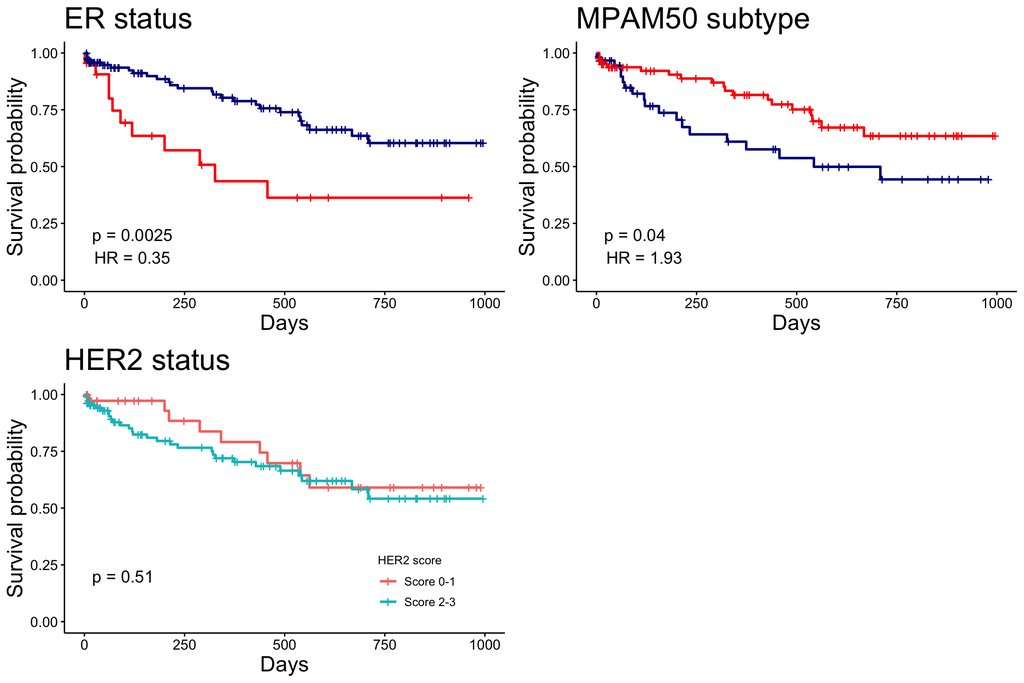

```r
arrange_ggsurvplots(list(ER.plot, HER2.plot, MPAM.plot), nrow = 2, ncol=2)
```

```r
ggsave(file = "plots/KMplot_ER.png", plot= print(ER.plot$plot), height = 4.1, width = 5.7)
```

```r
ggsave(file = "plots/KMplot_MPAM.png", plot= print(MPAM.plot$plot), height = 4.1, width = 5.7)
```

```r
ggsave(file = "plots/KMplot_lymph.png", plot= print(Lymph_inv.plot$plot), height = 2.75, width = 3.85)
```

```r
ggsave(file = "plots/KMplot_grade.png", plot= print(Grade.1.plot$plot), height = 2.75, width = 3.85)
```

```r
ggsave(file = "plots/KMplot_age.png", plot= print(Age.plot$plot), height = 2.75, width = 3.85)
```

## 4) Univariate cox models

In this section we will be exploring the clinical variables in univariate Cox models to see which variables should probably be included in a survival model. From the table we can see that the findings in the log-rank test is in concordance with the univariate Cox models.

Prior to model fitting, all clinical variables are one-hot encoded and age is scaled.

We do not correct for multiple testing here because this is not our final model, it is just a pre-filtering step of clinical variables.

```r
## Standardizing numerical variables in clinical_tbl and 0-1 encoding categorical variables with two levels
clinical_onehot <- clinical_tbl %>%
  mutate(Age_scaled = as.numeric(scale(Age, center=T, scale=T))) %>%
  mutate(Lymphatic_invasion_present = as.factor(ifelse(Lymphatic_invasion == "Present", 1, 0)),
         is_carcinoma = ifelse(Histology_gr == "Carcinomas", 1, 0)) %>%
  mutate(is_ER_positive = as.factor(ifelse(ER_status == "P", 1, 0))) %>%
  mutate(is_Neutered = as.factor(ifelse(Neuter_status == "Neutered", 1, 0))) %>%
  mutate(is_Basal_subtype = as.factor(ifelse(Subtype_MPAM50 == "Basal", 1, 0))) %>%
  mutate(is_Maltese = as.factor(ifelse(Breed_Maltese == "Maltese", 1, 0))) %>%
  mutate(Grade_1 = ifelse(Grade=="1", 1, 0),
         Grade_2 = ifelse(Grade=="2", 1, 0),
         Grade_3 = ifelse(Grade=="3", 1, 0)) %>%
  mutate(HER2_score_1 = ifelse(HER2_score=="1", 1, 0),
         HER2_score_2 = ifelse(HER2_score=="2", 1, 0),
         HER2_score_3 = ifelse(HER2_score=="3", 1, 0)) %>%
  column_to_rownames(var= "Sample_ID") %>%
  select(Status_survival, Survival_days,c(20:32))


#### Result table for storing univariate test results
vec_param <- colnames(clinical_onehot[3:ncol(clinical_onehot)])
results_table <- tibble(parameter = vec_param, logrank.p = NA, cox.single.hazard = NA, cox.single.p =NA)
response <- Surv(clinical_onehot$Survival_days, clinical_onehot$Status_survival) #defining outcome variable

# For loop running univariate cox models
results_table$cox.single.p <- vapply(vec_param, function(variable){
    model <- coxph(as.formula(sprintf("Surv(Survival_days, Status_survival) ~ %s", variable)), data = clinical_onehot)
    summary(model)$coefficients[,"Pr(>|z|)"]
  }, numeric(1))

results_table$cox.single.hazard <- vapply(vec_param, function(variable){
  model <- coxph(as.formula(sprintf("Surv(Survival_days, Status_survival) ~ %s", variable)), data = clinical_onehot)
  summary(model)$coefficients[,"exp(coef)"]
}, numeric(1))

# Running logrank tests and storing p-value in results_table
for(i in vec_param){
  surv_diff <- survdiff(response ~ get(i), data = clinical_onehot)
  correct_row <- which(results_table$parameter == i)
  results_table$logrank.p[correct_row] <- surv_diff$pvalue
}

results_table <- results_table %>%
  mutate(Cox.single.sign = ifelse(cox.single.p<0.05, "Yes", "No")) %>%
  mutate(logrank.sign = ifelse(logrank.p<0.05, "Yes", "No")) %>%
  dplyr::select(parameter, logrank.p, logrank.sign, everything())

datatable(results_table, options = list(pageLength = 14, scrollX = T), caption = htmltools::tags$caption(style = 'caption-side: top; text-align: left;', 'Effect of parameter on survival')) %>% formatStyle("logrank.sign", background = styleEqual(unique(results_table$logrank.sign), c('lightgreen', 'pink'))) %>% formatStyle("Cox.single.sign", background = styleEqual(unique(results_table$Cox.single.sign), c('lightgreen', 'pink')))
```

|  | parameter | logrank.p | logrank.sign | cox.single.hazard | cox.single.p | Cox.single.sign |
| --- | --- | --- | --- | --- | --- | --- |
| 1 | Age_scaled | 0.0157421393481541 | Yes | 2.20620555813207 | 0.000137164737596553 | Yes |
| 2 | Lymphatic_invasion_present | 2.04819326986295e-05 | Yes | 4.37552068320849 | 9.21808831244649e-05 | Yes |
| 3 | is_carcinoma | 0.117303545119364 | No | 1.98126907828535 | 0.124563950772213 | No |
| 4 | is_ER_positive | 0.00249359003448925 | Yes | 0.353070029528381 | 0.00379695091886671 | Yes |
| 5 | is_Neutered | 0.554411643942404 | No | 1.22396655631578 | 0.554833371918431 | No |
| 6 | is_Basal_subtype | 0.0398619766541032 | Yes | 1.93177775041644 | 0.0434415673073748 | Yes |
| 7 | is_Maltese | 0.902038546735175 | No | 1.04432128369493 | 0.90121877390894 | No |
| 8 | Grade_1 | 0.161744639155872 | No | 0.627219856099871 | 0.165875317180002 | No |
| 9 | Grade_2 | 0.681568092976053 | No | 1.19938161481562 | 0.683845879727952 | No |
| 10 | Grade_3 | 7.26219939162711e-05 | Yes | 3.54287333008883 | 0.000194324462276703 | Yes |

[output cut: 3 more lines]

## 5) Multivariate Cox model

### Multivariate cox model

#### Stepwise regression, “both” selection

```r
res.cox.empty <- coxph(Surv(clinical_onehot$Survival_days, clinical_onehot$Status_survival) ~ 1, data = clinical_onehot)
fit.best.both <- MASS::stepAIC(res.cox.empty, direction = "both", scope=list(lower=res.cox.empty, upper= ~ Age_scaled + Lymphatic_invasion_present + is_ER_positive + is_Basal_subtype + Grade_3))
```

The model chosen by stepwise regression includes three parameters: Age, Lymphatic invasion and ER status. Neither Grade 3 nor MPAM50 subtype, which were significant in univariate models, were included in a multivariate model.

```r
summary(fit.best.both)
```

```
## Call:
## coxph(formula = Surv(clinical_onehot$Survival_days, clinical_onehot$Status_survival) ~
##     Age_scaled + Lymphatic_invasion_present + is_ER_positive,
##     data = clinical_onehot)
##
##   n= 146, number of events= 38
##
##                                coef exp(coef) se(coef)      z Pr(>|z|)
## Age_scaled                   0.5608    1.7520   0.2156  2.601   0.0093 **
## Lymphatic_invasion_present1  0.9591    2.6093   0.4244  2.260   0.0238 *
## is_ER_positive1             -0.8218    0.4397   0.3639 -2.258   0.0239 *
## ---
## Signif. codes:  0 '***' 0.001 '**' 0.01 '*' 0.05 '.' 0.1 ' ' 1
##
##                             exp(coef) exp(-coef) lower .95 upper .95
## Age_scaled                     1.7520     0.5708    1.1482    2.6735
## Lymphatic_invasion_present1    2.6093     0.3832    1.1357    5.9952
## is_ER_positive1                0.4397     2.2745    0.2154    0.8972
##
## Concordance= 0.718  (se = 0.041 )
## Likelihood ratio test= 25.3  on 3 df,   p=1e-05
## Wald test            = 27.08  on 3 df,   p=6e-06
## Score (logrank) test = 31.45  on 3 df,   p=7e-07
```

```r
tab_model(data = fit.best.both, title = "Multivariate cox model", string.est = "Hazard", file = "plots/Results_table_multivariate.doc") #saving the model, dont know if actually works
```

Multivariate cox model

|  | Dependent variable |  |  |
| --- | --- | --- | --- |
| Predictors | Hazard | CI | p |
| Age scaled | 1.75 | 1.15 – 2.67 | **0.009** |
| Lymphatic invasion present [1] | 2.61 | 1.14 – 6.00 | **0.024** |
| is ER positive [1] | 0.44 | 0.22 – 0.90 | **0.024** |
| Observations | 146 |  |  |
| R<sup>2</sup> Nagelkerke | 0.178 |  |  |

## 6) Correlations

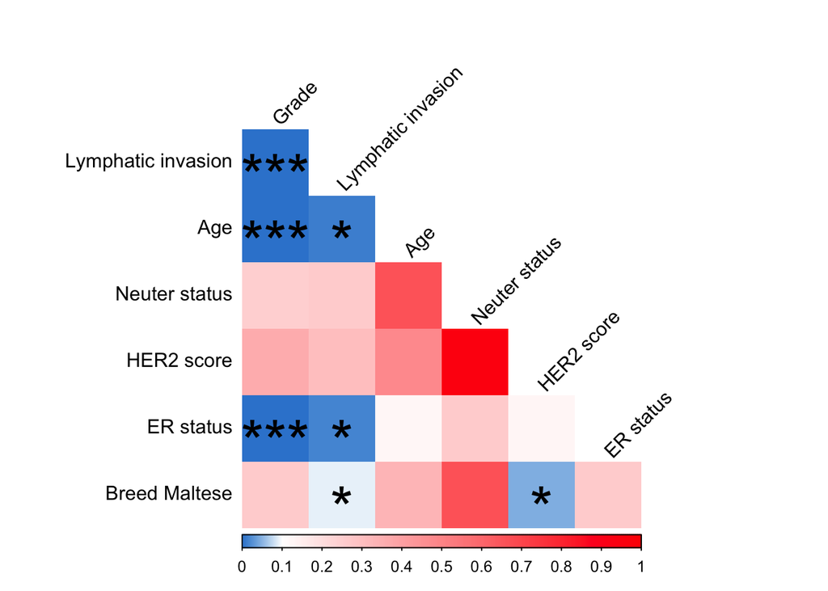

```r
clinical_notonehot <- clinical_tbl %>%
  mutate(Age = as.numeric(scale(Age, center=T, scale=T))) %>%
  column_to_rownames(var= "Sample_ID") %>%
  select(c(1:7,9)) %>%
  mutate_if(is.factor, as.numeric)

corr_matrix <- matrix(nrow = ncol(clinical_notonehot), ncol = ncol(clinical_notonehot), dimnames = list(colnames(clinical_notonehot), colnames(clinical_notonehot)))

for (i in colnames(clinical_notonehot)) {
  for (j in colnames(clinical_notonehot)) {
    if (i == "Age" | j == "Age"){ #Age is only continous variable, test
      corr <- stats::cor.test(clinical_notonehot[,i], clinical_notonehot[,j], method = "pearson")
      corr_matrix[j,i]  <- corr$p.value
    }
    else{ #for two categorical variables, association is tested with chi squared
      chi2 = chisq.test(clinical_notonehot[,i],clinical_notonehot[,j], correct=F)
      corr_matrix[j,i] <- chi2$p.value
    }
  }
}

corr_matrix_adjust <- corr_matrix %>%
  as.matrix %>%
  as.vector %>%
  p.adjust(method='fdr') %>%
  matrix(ncol=8) %>%
  `rownames<-`(rownames(corr_matrix)) %>%
  `colnames<-`(colnames(corr_matrix))

colnames(corr_matrix_adjust) <- colnames(corr_matrix_adjust) %>% str_replace_all(., "_", " ")
rownames(corr_matrix_adjust) <- rownames(corr_matrix_adjust) %>% str_replace_all(., "_", " ")
corr_matrix_adjust_plot <- corr_matrix_adjust[1:7,1:7]


corrplot::corrplot(corr =corr_matrix_adjust_plot,
                   method = "shade",
                   is.corr = F,
                   col.lim = c(0,1),
                   col=colorRampPalette(c("#3686D3","white","#FFE5E5", "#FFCCCC","#FFB2B2", "#FF9999", "#FF7F7F", "#FF5F5F","#FF3F3F", "#FF1F1F", "#FF0000"))(200),
                  p.mat = corr_matrix_adjust_plot,
                   sig.level = c(0.001, 0.01, 0.1),
                   outline = T,
                   insig = "label_sig",
                   tl.col = "black",
                   order = "hclust",
                   type = "lower",
                   diag = F,
                   tl.srt = 45)
```

## 7) Checking assumptions

We will now check the assumptions for the model chosen by stepwise regression, as described here: http://www.sthda.com/english/wiki/cox-model-assumptions . The assumptions for cox proportional hazards models are:

- proportionalhazards over time and
- linear relationships between each covariate and the log hazard.

```r
test.ph <- cox.zph(fit.best.both)
test.ph
```

```
##                            chisq df    p
## Age_scaled                 0.108  1 0.74
## Lymphatic_invasion_present 0.302  1 0.58
## is_ER_positive             0.632  1 0.43
## GLOBAL                     1.122  3 0.77
```

**Test for non-linearity**  
Only relevant for age as the other two variables are binominal. Here, linearity for age is tested for the standardized age-values. https://www.bookdown.org/rwnahhas/RMPH/survival-linearity.html

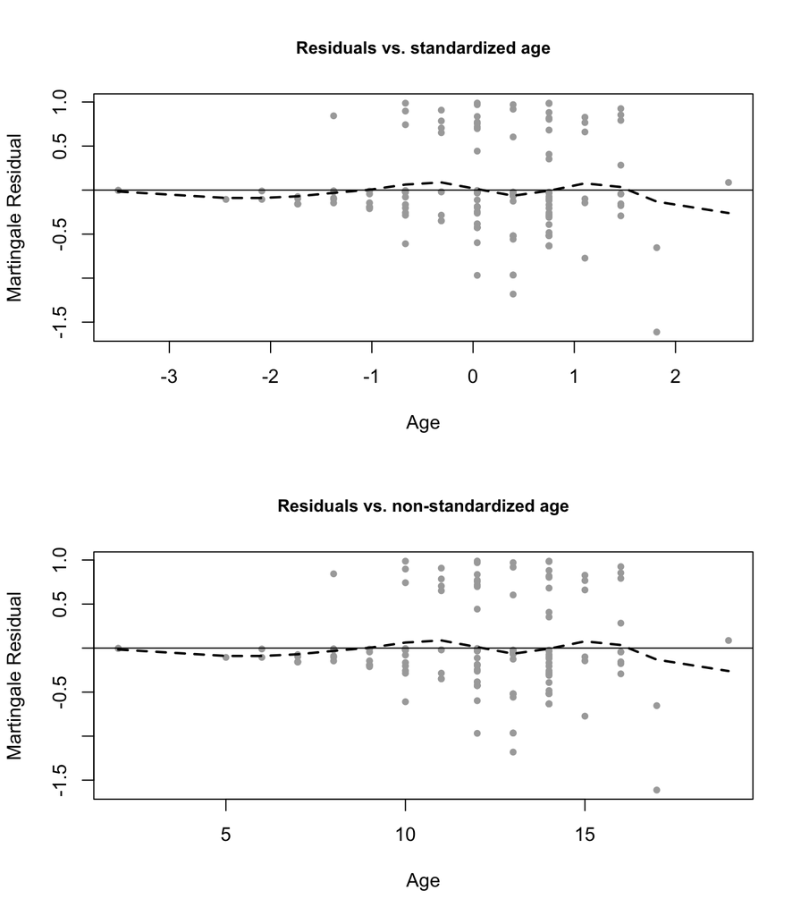

```r
#ggcoxfunctional(Surv(clinical_tbl$Survival_days, clinical_tbl$Status_survival) ~ Age + log(Age) + sqrt(Age), data = clinical_tbl) # This function does not work when Age is standardized (cannot do log or sqrt of negative numbers)

par(mfrow = c(2,1))

Y <- resid(coxph(Surv(clinical_onehot$Survival_days, clinical_onehot$Status_survival) ~ Age_scaled + Lymphatic_invasion_present + is_ER_positive, data = clinical_onehot), type = "martingale")
X <- clinical_onehot$Age

plot(X,Y, pch = 20, col = "darkgray",
     xlab = "Age", ylab = "Martingale Residual",
     main = "Residuals vs. standardized age",
     cex.main = 0.90)

abline(h = 0)
lines(smooth.spline(X, Y, df = 7), lty = 2, lwd = 2)

Y <- resid(coxph(Surv(clinical_tbl$Survival_days, clinical_tbl$Status_survival) ~ Age_nonstd + Lymphatic_invasion + ER_status, data = clinical_tbl), type = "martingale")
X <- clinical_tbl$Age_nonstd

plot(X,Y, pch = 20, col = "darkgray",
     xlab = "Age", ylab = "Martingale Residual",
     main = "Residuals vs. non-standardized age",
     cex.main = 0.90)

abline(h = 0)
lines(smooth.spline(X, Y, df = 7), lty = 2, lwd = 2)
```

**Testing influencial observations**  
Explanation for the first plots from website: “Specifying the argument type =”dfbeta”, plots the estimated changes in the regression coefficients upon deleting each observation in turn; likewise, type=“dfbetas” produces the estimated changes in the coefficients divided by their standard errors.” http://www.sthda.com/english/wiki/cox-model-assumptions

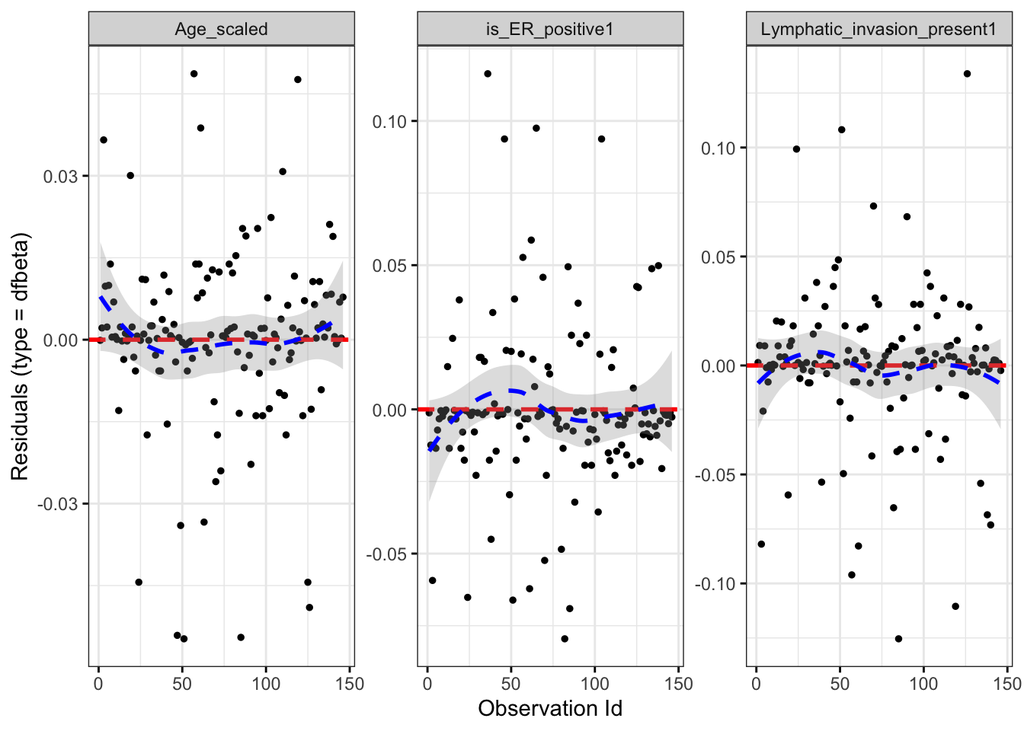

```r
ggcoxdiagnostics(fit.best.both, type = "dfbeta",
                 linear.predictions = FALSE, ggtheme = theme_bw())
```

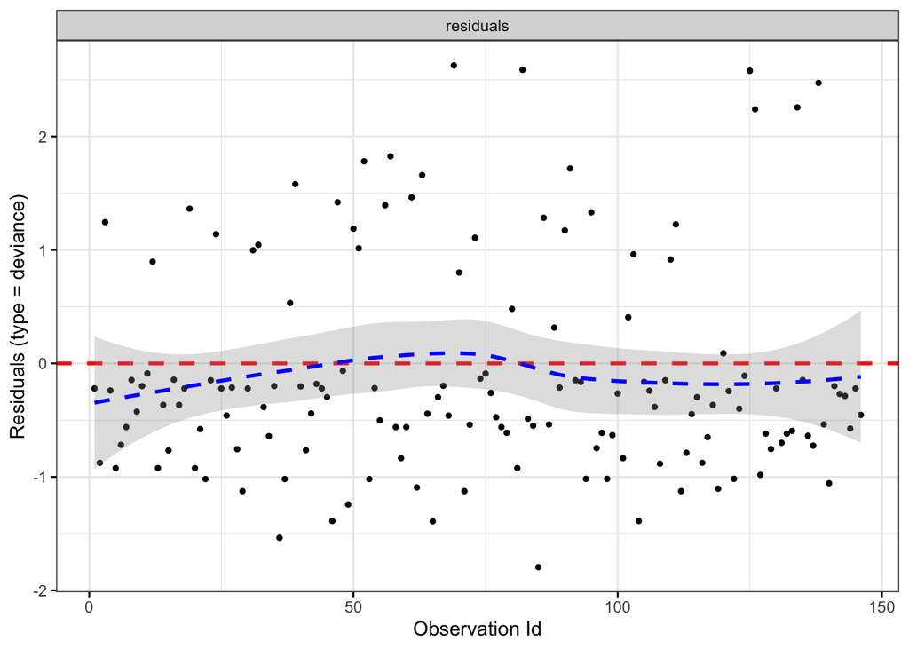

```r
ggcoxdiagnostics(fit.best.both, type = "deviance",
                 linear.predictions = FALSE, ggtheme = theme_bw())
```